# Estudo de Análise de Séries Temporais

# Processos Estocásticos

É uma família de variáveis aleatórias, que supomos definidas num mesmo espaço de probabilidades.

São conjunto de variáveis aleatórias medidas ao longo do tempo

Séries temporais podem ser definidas como *uma realização de um processo estocástico*

## Estacionariedade

Intuitivamente, um processo $Z$ é estacionário se ele desenvolve no tempo de modo que a escolha de uma origem dos tempos não é importante.

Em outras palavras, as características de $Z(t+\tau)$, para todo $\tau$, são as mesmas de $Z(t)$.

Tecnicamente, existem duas formas de estacionariedade:

- fraca (ou ampla, ou de segunda ordem)
- estrita (ou forte)

Uma série é dita estacionária quando ela se desenvolve no tempo aleatoriamente ao redor de uma média constante e variância constante, refletindo alguma forma de equilíbrio estável.

É uma das suposições mais frequêntes que se faz a respeito de uma série temporal e por este motivo na maioria, será necessário transformar os dados originais caso estes não formem uma série estacionária.

### Ruído branco ($\epsilon_t$)

O ruído branco é um processo estocástico no qual $RB \sim id(0,\sigma_{\epsilon_t}^2)$

### Obtendo a estacionariedade fazendo diferenças

A transformação mais comum para se a série se torne estacionária consiste em tomar **diferenças** sucessivas da série original, até se obter uma série estacionária. De modo geral:

$$\Delta^nZt(t)=\Delta[\Delta^{n-1}Z(t)].$$

```r
# Diferenciar a série para tirar a tendência
diff(AirPassengers)
```

```
##       Jan  Feb  Mar  Apr  May  Jun  Jul  Aug  Sep  Oct  Nov  Dec
## 1949         6   14   -3   -8   14   13    0  -12  -17  -15   14
## 1950   -3   11   15   -6  -10   24   21    0  -12  -25  -19   26
## 1951    5    5   28  -15    9    6   21    0  -15  -22  -16   20
## 1952    5    9   13  -12    2   35   12   12  -33  -18  -19   22
## 1953    2    0   40   -1   -6   14   21    8  -35  -26  -31   21
## 1954    3  -16   47   -8    7   30   38   -9  -34  -30  -26   26
## 1955   13   -9   34    2    1   45   49  -17  -35  -38  -37   41
## 1956    6   -7   40   -4    5   56   39   -8  -50  -49  -35   35
## 1957    9  -14   55   -8    7   67   43    2  -63  -57  -42   31
## 1958    4  -22   44  -14   15   72   56   14 -101  -45  -49   27
## 1959   23  -18   64  -10   24   52   76   11  -96  -56  -45   43
## 1960   12  -26   28   42   11   63   87  -16  -98  -47  -71   42
```

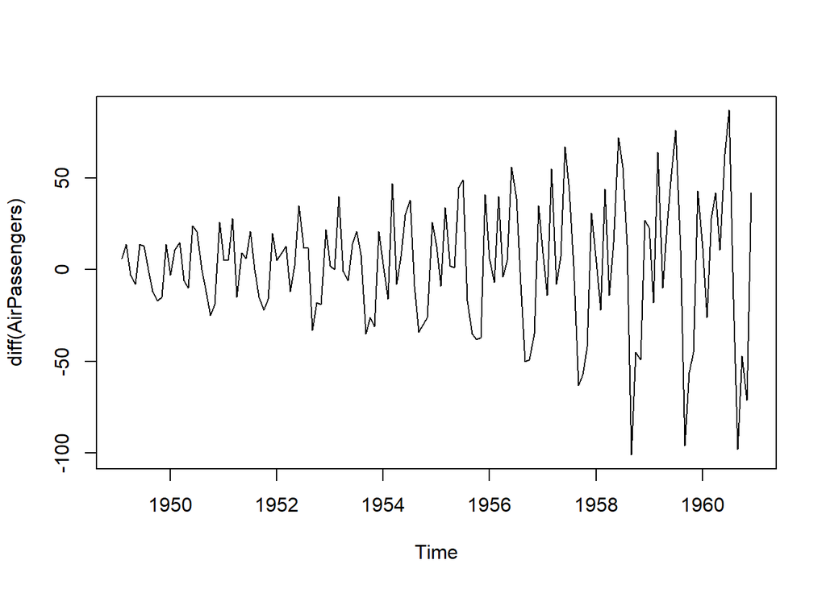

```r
plot(diff(AirPassengers))
```